# GDP and Aviation Accident Rates by Year, 2002–2023

Dongqi Mo

2026-11-25

## Introduction

I wanted to see whether economies with higher GDP tend to have higher or lower aviation accident rates. For this analysis, I used annual data from 2002 to 2023.

## Data and methods

I used the GDP and aviation CSVs already in our GitHub repository. I converted the GDP year columns into rows and matched the two tables by country code and year. Each matched row has one economy’s GDP, accident count, and departures for one year. I kept years with zero accidents if they had GDP and departure data.

```r
repo <- "https://raw.githubusercontent.com/ChrisSimoneau/HCIN5400/"
gdp_wide <- read.csv(
  paste0(repo, "de40a22a8386e69549ad1f7a46ae0a8a65c7da1c/",
         "gdp_annual_and_statistics_by_country.csv"),
  check.names = FALSE
)
flights <- read.csv(
  paste0(repo, "c1dc63208652d0264e16dddd2d9525d455a9dd08/",
         "accidents_departures_country_year_2002_2023.csv")
)
```

```r
gdp <- data.frame()
for (year in 2002:2023) {
  one_year <- data.frame(
    country_code = gdp_wide$Code,
    year = year,
    gdp_current_usd = gdp_wide[[as.character(year)]]
  )
  gdp <- rbind(gdp, one_year)
}
```

```r
stopifnot(!anyDuplicated(flights[c("Country.Code", "Year")]),
          !anyDuplicated(gdp[c("country_code", "year")]))
```

```r
annual <- merge(flights, gdp,
                by.x = c("Country.Code", "Year"),
                by.y = c("country_code", "year"),
                all.x = TRUE)

model_data <- subset(annual, Departures > 0 & gdp_current_usd > 0 &
                       is.finite(Accidents) & Accidents >= 0)
model_data$log2_gdp <- log2(model_data$gdp_current_usd)
```

The CSV below contains the same rows used in the regression. The accident rate column is included for reference.

```r
regression_data <- model_data[c("Country.Name", "Country.Code", "Year",
                                "gdp_current_usd", "Accidents", "Departures")]
regression_data$Accidents_per_million <- model_data$Accidents_per_million
write.csv(regression_data, "gdp_annual_regression_data_with_rates.csv",
          row.names = FALSE)
```

```r
fit <- glm(
  Accidents ~ log2_gdp + factor(Year),
  offset = log(Departures),
  family = poisson(),
  data = model_data,
  na.action = na.fail
)
round(exp(coef(fit)[["log2_gdp"]]), 3)
```

```
## [1] 0.777
```

```r
n <- nobs(fit)
scores <- model.matrix(fit) * (model_data$Accidents - fitted(fit))
country_scores <- rowsum(scores, model_data$Country.Code)
economies <- nrow(country_scores)

# Calculate the clustered standard error for the GDP coefficient.
gdp_weights <- vcov(fit)[, "log2_gdp"]
adjustment <- economies / (economies - 1) * (n - 1) / (n - fit$rank)
se <- sqrt(adjustment * sum((country_scores %*% gdp_weights)^2))
estimate <- coef(fit)[["log2_gdp"]]
rate_ratio <- exp(estimate)
percent_lower <- 100 * (1 - rate_ratio)
ci <- exp(estimate + c(-1, 1) * qt(.975, economies - 1) * se)

data.frame(
  Annual_records = n,
  Economies = economies,
  Rate_ratio = round(rate_ratio, 3),
  Percent_lower = round(percent_lower, 1),
  CI_lower = round(ci[1], 3),
  CI_upper = round(ci[2], 3)
)
```

```
##   Annual_records Economies Rate_ratio Percent_lower CI_lower CI_upper
## 1           3277       173      0.777          22.3    0.737     0.82
```

## Figure 1. Estimated accident rate ratio

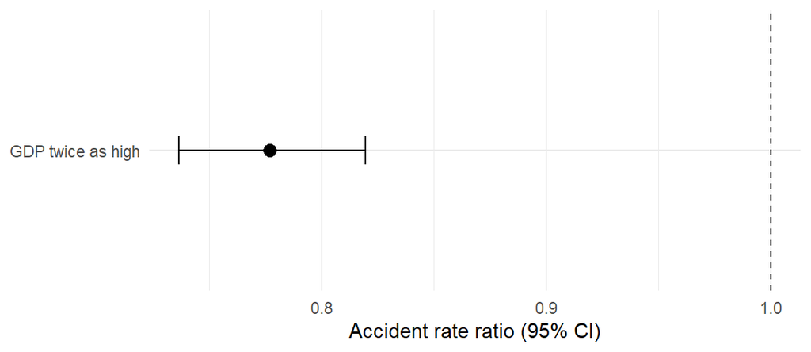

```r
library(ggplot2)

plot_data <- data.frame(
  estimate = rate_ratio, lower = ci[1], upper = ci[2],
  comparison = "GDP twice as high"
)

ggplot(plot_data, aes(x = estimate, y = comparison)) +
  geom_vline(xintercept = 1, linetype = "dashed") +
  geom_errorbar(aes(xmin = lower, xmax = upper), orientation = "y", width = 0.12) +
  geom_point(size = 3) +
  labs(x = "Accident rate ratio (95% CI)", y = NULL) +
  theme_minimal()
```

## Results

The regression included 3,277 annual records from 173 economies. When comparing two economies in the same year, the model estimated that an economy with twice the GDP of the other had a 22% lower recorded accident rate per departure. The estimated rate ratio was 0.777 (95% confidence interval: 0.737 to 0.820).